# Fashion MNIST

Elias Junior Ghantous and Sebastian Bigelow-Mirmiran

December 12, 2019

```r
library(readr)
library(dplyr)
```

```r
library(ggplot2)
library(FactoMineR)
library(RColorBrewer)
library(caret)
library(pROC)
library(gbm)
library(e1071)
```

```r
FMNIST <- read_csv("FashionMNIST.csv")
y <- FMNIST$label
y[y == 0] <- "shirt"
y[y == 1] <- "pant"
y[y == 2] <- "shoe"
X <- subset(FMNIST, select = -c(label))
rm('FMNIST')
set.seed(12345)
```

### Exploratory PCA

```r
PCA_results <- PCA(X, ncp = ncol(X))
```

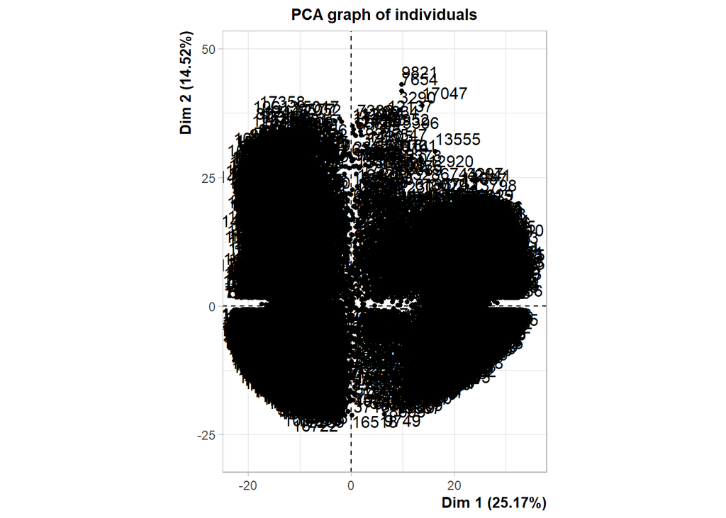

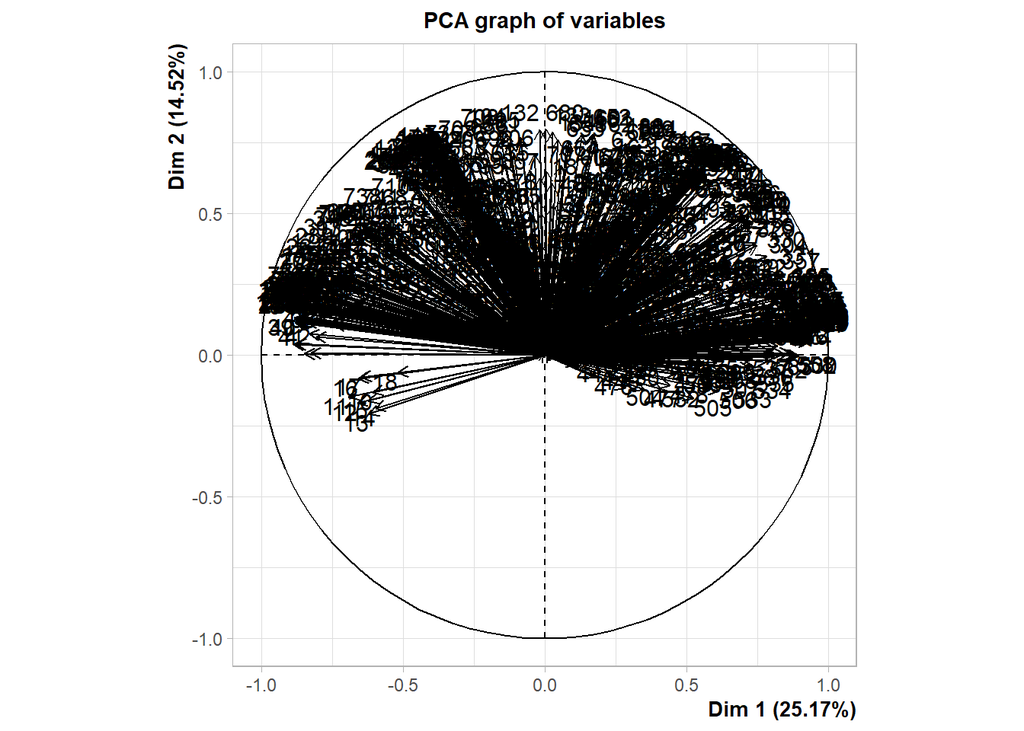

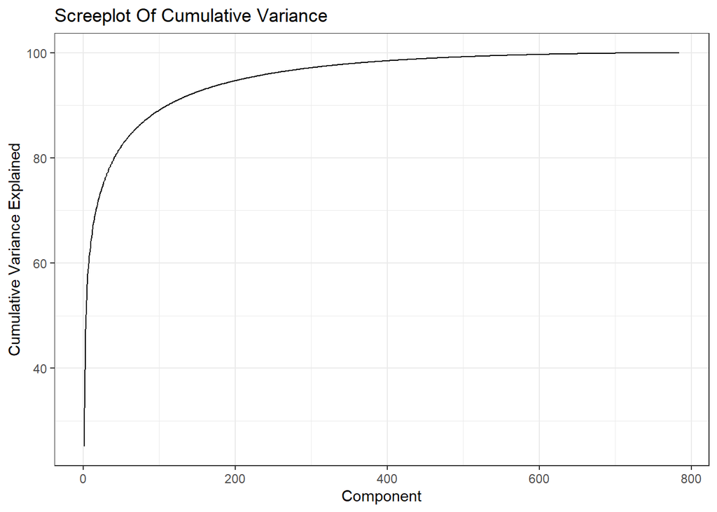

```r
screeplot_data <- as.data.frame(PCA_results$eig)
ggplot(data = screeplot_data, aes(x = 1:nrow(screeplot_data), y = screeplot_data[,3])) + geom_line() + theme_bw() + ylab("Cumulative Variance Explained") + xlab("Component") + ggtitle("Screeplot Of Cumulative Variance")
```

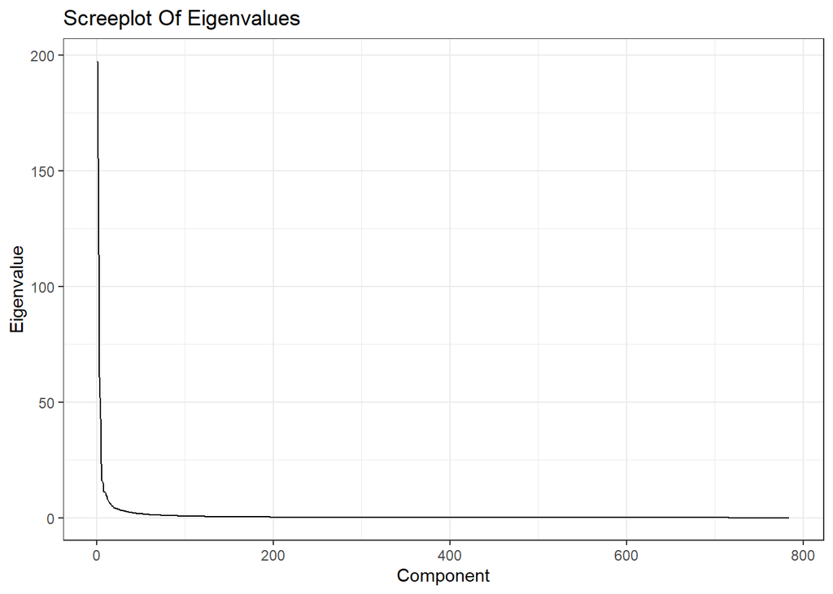

```r
ggplot(data = screeplot_data, aes(x = 1:nrow(screeplot_data), y = screeplot_data[,1])) + geom_line() + theme_bw() + ylab("Eigenvalue") + xlab("Component") + ggtitle("Screeplot Of Eigenvalues")
```

#### Making Sense of PCA (Transforming the Data)

```r
# transforming eigenvalues
loadings <- sweep(PCA_results$var$coord,2,sqrt(PCA_results$eig[1:ncol(PCA_results$var$coord),1]),FUN="/")

# making sense of loadings
loadings <- abs(loadings)
loading_sums <- rowSums(loadings)
loadings_df <- cbind(loading_sums, c(1:length(loading_sums)))
loadings_df <- loadings_df[order(-loading_sums),]
colnames(loadings_df) <- c("loading sum", "columnnumber")

# finding the most significant columns from PCA
top_pic_pixels <- head(loadings_df[,2], 200)
X_compressed <- X[,sort(top_pic_pixels, decreasing = FALSE)]
```

We selected the top 200 pixels as that was a significant reduction in dimensionality while still being able to distinguish between classes visually. The 200 mark is one in general that explains around 95% of the variance.

### Visualizing Images After PCA

In order to make the images as identifiable as possible, we used a colour scale that includes 9 colours and replaced all null values with NA. This allowed us to identify which pixels of the original image were the result of PCA analysis i.e. the most significant pixels.

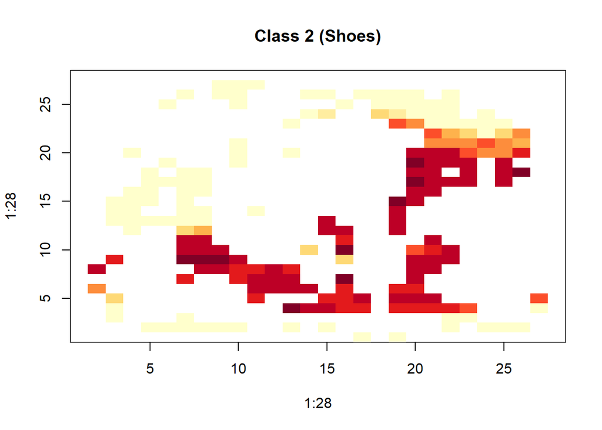

```r
# shoe
X2 <- as.numeric(X[1,])
X2[-top_pic_pixels] <- NA
X2 <- matrix(X2, ncol=28, nrow=28, byrow = TRUE)
X2 <- apply(X2, 2, rev)
image(1:28, 1:28,t(X2), col = brewer.pal(n = 9, name = "YlOrRd"), main='Class 2 (Shoes)')
```

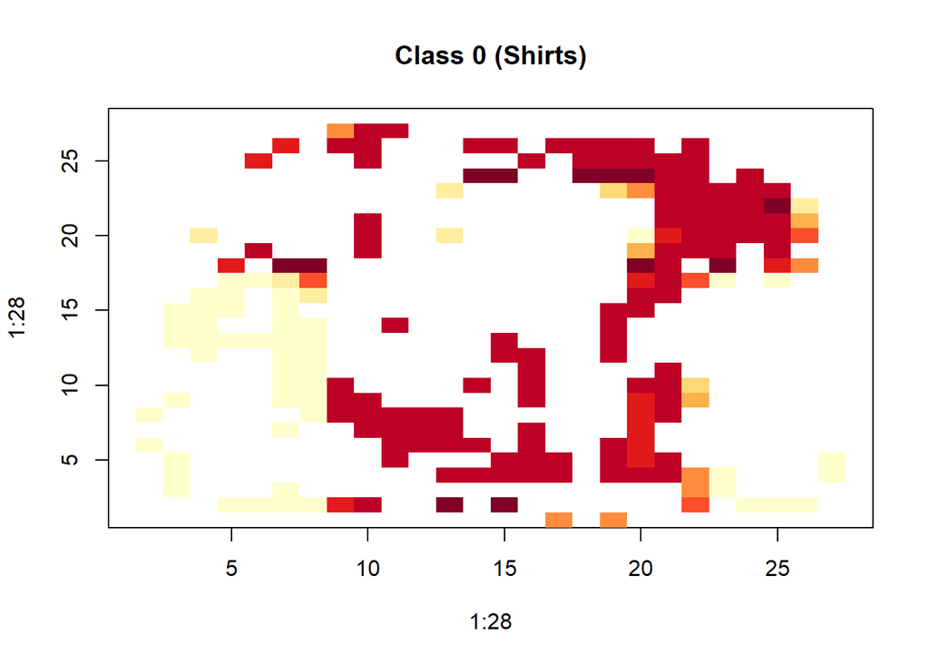

```r
# shirt
X0 <- as.numeric(X[2,])
X0[-top_pic_pixels] <- NA
X0 <- matrix(X0, ncol=28, nrow=28, byrow = TRUE)
X0 <- apply(X0, 2, rev)
image(1:28, 1:28,t(X0), col = brewer.pal(n = 9, name = "YlOrRd"), main='Class 0 (Shirts)')
```

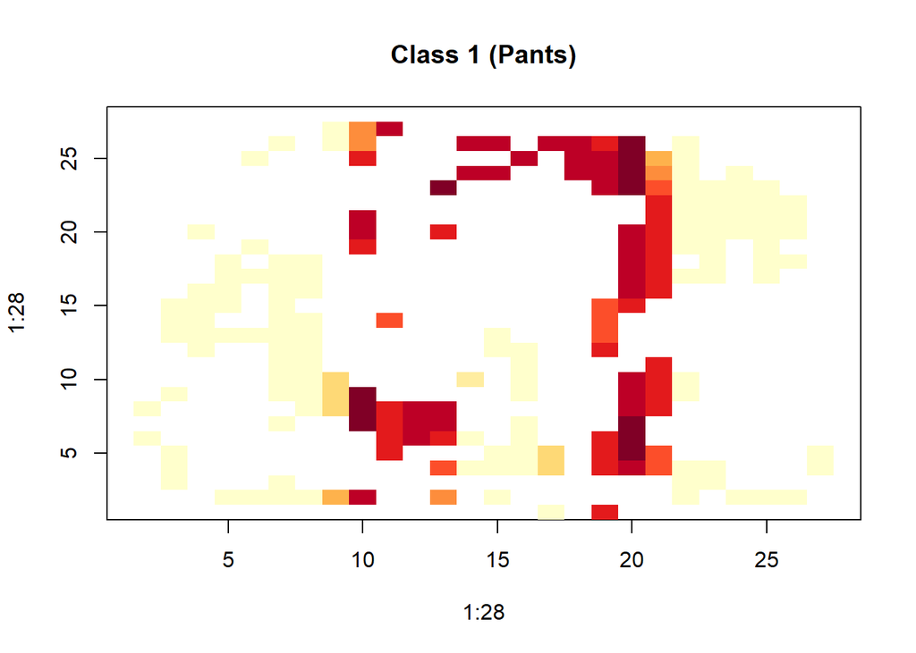

```r
# pants

X1 <- as.numeric(X[8,])
X1[-top_pic_pixels] <- NA
X1 <- matrix(X1, ncol=28, nrow=28, byrow = TRUE)
X1 <- apply(X1, 2, rev)
image(1:28, 1:28,t(X1), col = brewer.pal(n = 9, name = "YlOrRd"), main='Class 1 (Pants)')
```

To try and find the lowest dimensionality that allows us to still visually distinguish between the three classes, we tested at lower dimensions. We found that the minimum was 100 pixels. This does, however, make it difficult to distinguish pants from shirts correctly every time.

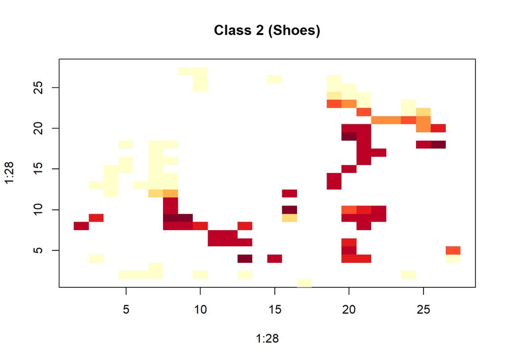

```r
top_pic_pixels <- head(loadings_df[,2], 100)
X_compressed <- X[,sort(top_pic_pixels, decreasing = FALSE)]

# shoe
X2 <- as.numeric(X[1,])
X2[-top_pic_pixels] <- NA
X2 <- matrix(X2, ncol=28, nrow=28, byrow = TRUE)
X2 <- apply(X2, 2, rev)
image(1:28, 1:28,t(X2), col = brewer.pal(n = 9, name = "YlOrRd"), main='Class 2 (Shoes)')
```

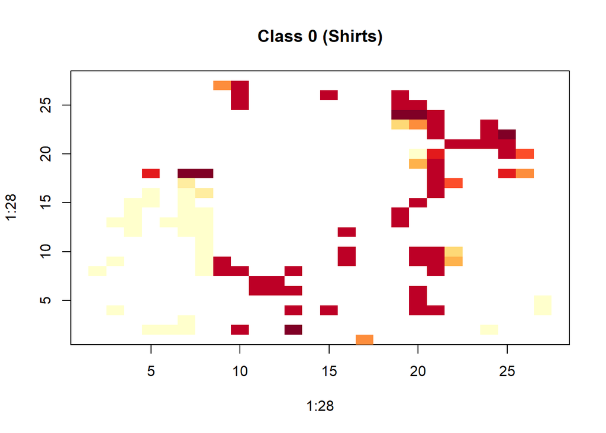

```r
# shirt
X0 <- as.numeric(X[2,])
X0[-top_pic_pixels] <- NA
X0 <- matrix(X0, ncol=28, nrow=28, byrow = TRUE)
X0 <- apply(X0, 2, rev)
image(1:28, 1:28,t(X0), col = brewer.pal(n = 9, name = "YlOrRd"), main='Class 0 (Shirts)')
```

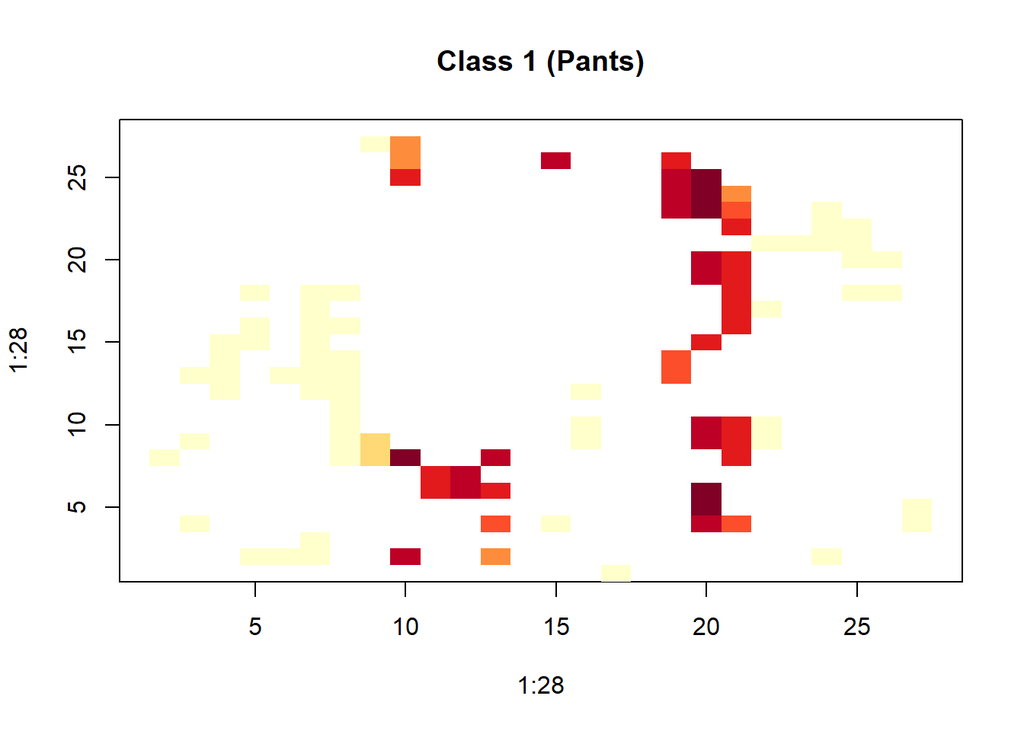

```r
# pants

X1 <- as.numeric(X[8,])
X1[-top_pic_pixels] <- NA
X1 <- matrix(X1, ncol=28, nrow=28, byrow = TRUE)
X1 <- apply(X1, 2, rev)
image(1:28, 1:28,t(X1), col = brewer.pal(n = 9, name = "YlOrRd"), main='Class 1 (Pants)')
```

### Binary Classification

#### Shoes VS Shirts

```r
shoes_shirts <- which(y %in% c("shoe","shirt"))
holdout_shoes_shirts_split <- sample.int(length(shoes_shirts)*0.2)
holdout_shoes_shirts <- shoes_shirts[holdout_shoes_shirts_split]
shoes_shirts <- shoes_shirts[-holdout_shoes_shirts_split]
shoes_shirts_train_split <- sample.int(length(shoes_shirts)*0.8)
shoes_shirts_train <- shoes_shirts[shoes_shirts_train_split]
shoes_shirts_test <- shoes_shirts[-shoes_shirts_train_split]

# running PCA on training set
PCA_results <- PCA(X[shoes_shirts_train,], ncp = ncol(X))
```

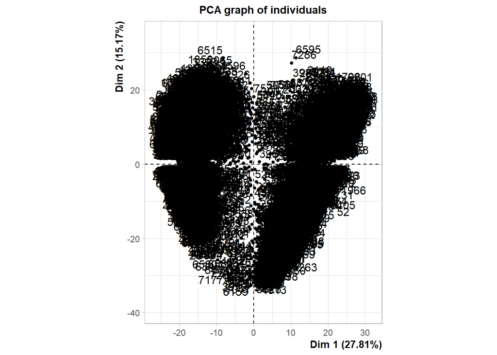

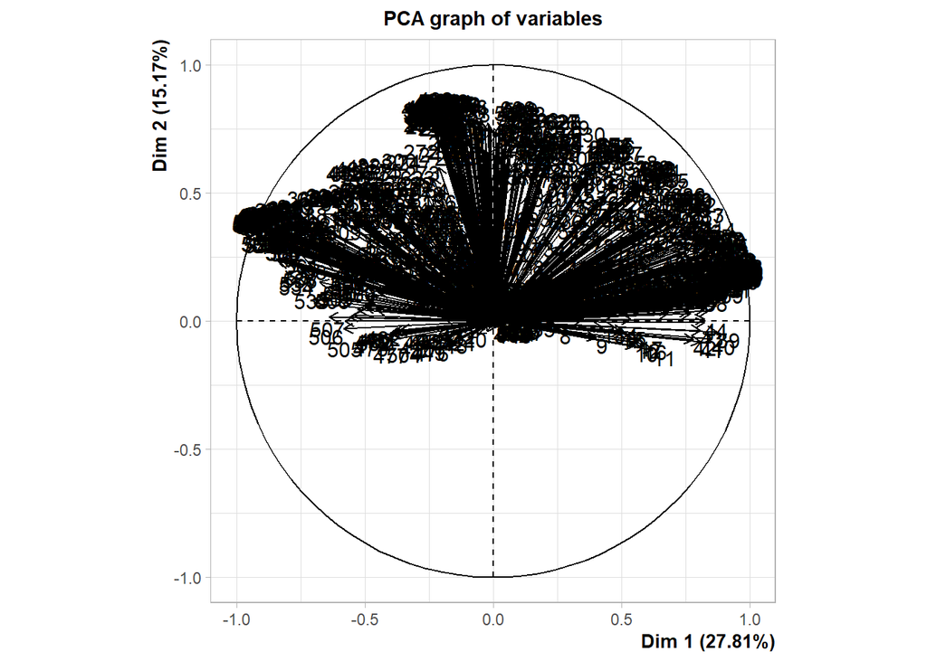

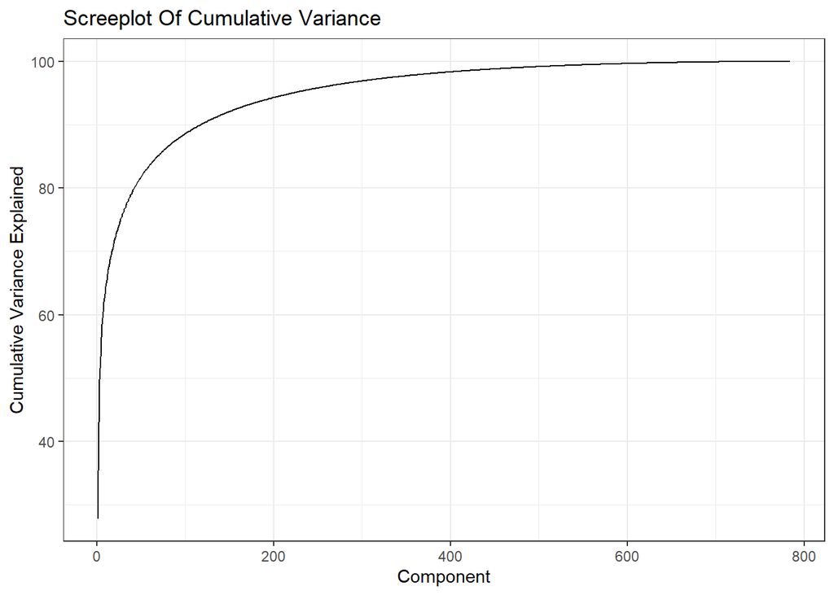

```r
screeplot_data <- as.data.frame(PCA_results$eig)
ggplot(data = screeplot_data, aes(x = 1:nrow(screeplot_data), y = screeplot_data[,3])) + geom_line() + theme_bw() + ylab("Cumulative Variance Explained") + xlab("Component") + ggtitle("Screeplot Of Cumulative Variance")
```

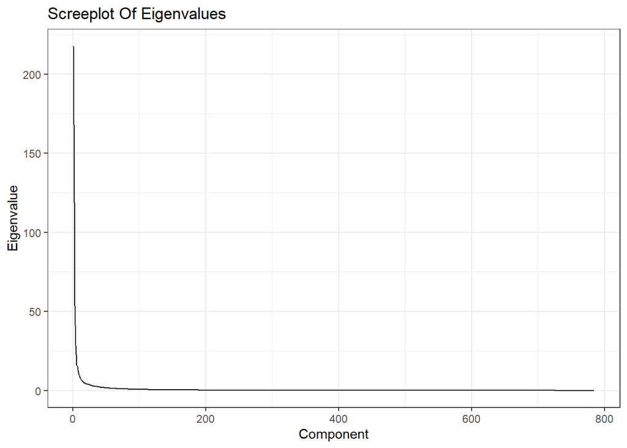

```r
ggplot(data = screeplot_data, aes(x = 1:nrow(screeplot_data), y = screeplot_data[,1])) + geom_line() + theme_bw() + ylab("Eigenvalue") + xlab("Component") + ggtitle("Screeplot Of Eigenvalues")
```

```r
# making sense of eigenvalues
loadings <- sweep(PCA_results$var$coord,2,sqrt(PCA_results$eig[1:ncol(PCA_results$var$coord),1]),FUN="/")

# making sense of loadings
loadings <- abs(loadings)
loading_sums <- rowSums(loadings)
loadings_df <- cbind(loading_sums, c(1:length(loading_sums)))
loadings_df <- loadings_df[order(-loading_sums),]
colnames(loadings_df) <- c("loading sum", "columnnumber")

# finding most significant pixels
top_pic_pixels <- head(loadings_df[,2], 200)
X_compressed <- X[,sort(top_pic_pixels, decreasing = FALSE)]

shoes_shirts_train_X <- X_compressed[shoes_shirts_train,]
shoes_shirts_test_X <- X_compressed[shoes_shirts_test,]

shoes_shirts_train_y <- as.factor(y[shoes_shirts_train])
shoes_shirts_test_y <- as.factor(y[shoes_shirts_test])

shoes_shirts_holdout_X <- X_compressed[holdout_shoes_shirts,]
shoes_shirts_holdout_y <- as.factor(y[holdout_shoes_shirts])

trainingData <- cbind.data.frame(shoes_shirts_train_X, shoes_shirts_train_y)
testingData <- cbind.data.frame(shoes_shirts_test_X, shoes_shirts_test_y)
```

##### Gradient Boosted Machines Model With Cross-Validation

```r
objControl <- trainControl(method='cv', number=3, returnResamp='none', summaryFunction = twoClassSummary, classProbs = TRUE)

objModel <- train(shoes_shirts_train_X, shoes_shirts_train_y,
                  method='gbm',
                  trControl = objControl,
                  metric = "ROC")
objModel
```

```
## Stochastic Gradient Boosting
##
## 7680 samples
##  200 predictor
##    2 classes: 'shirt', 'shoe'
##
## No pre-processing
## Resampling: Cross-Validated (3 fold)
## Summary of sample sizes: 5120, 5120, 5120
## Resampling results across tuning parameters:
##
##   interaction.depth  n.trees  ROC        Sens       Spec
##   1                   50      0.9999145  0.9956309  0.9952494
##   1                  100      0.9999853  0.9989720  0.9973608
##   1                  150      0.9999894  0.9994860  0.9981525
##   2                   50      0.9999825  0.9992290  0.9963051
##   2                  100      0.9999915  0.9992290  0.9973608
##   2                  150      0.9999915  0.9997430  0.9976247
##   3                   50      0.9999760  0.9994860  0.9963051
##   3                  100      0.9999921  0.9994860  0.9973608
##   3                  150      0.9999935  0.9997430  0.9978886
##
## Tuning parameter 'shrinkage' was held constant at a value of 0.1
##
## Tuning parameter 'n.minobsinnode' was held constant at a value of 10
## ROC was used to select the optimal model using the largest value.
## The final values used for the model were n.trees = 150, interaction.depth =
##  3, shrinkage = 0.1 and n.minobsinnode = 10.
```

```r
predictions <- predict(object=objModel, shoes_shirts_test_X, type='raw')
head(predictions)
```

```
## [1] shirt shirt shoe  shirt shoe  shirt
## Levels: shirt shoe
```

```r
print(postResample(pred=predictions, obs=as.factor(shoes_shirts_test_y)))
```

```
##  Accuracy     Kappa
## 0.9989583 0.9979166
```

```r
predictions <- predict(object=objModel, shoes_shirts_test_X, type='prob')
head(predictions)
```

```
##          shirt         shoe
## 1 9.993864e-01 6.135896e-04
## 2 9.995415e-01 4.585379e-04
## 3 8.496509e-05 9.999150e-01
## 4 9.999308e-01 6.923536e-05
## 5 7.538841e-05 9.999246e-01
## 6 9.999590e-01 4.095676e-05
```

The best model using GBM is the one with 150 trees and a depth of 3. The accuracy, however, is very high for all of the GBM models possible after cross-validation.

##### Logistic Classification Model

```r
logitMod <- glm(shoes_shirts_train_y ~ ., data=trainingData, family=binomial(link="logit"), maxit = 100)
fitted.results <- predict(logitMod,newdata=testingData,type='response')
fitted.results <- ifelse(fitted.results > 0.5,"shoe","shirt")
misClassificError <- mean(fitted.results != testingData$shoes_shirts_test_y)
print(paste('Accuracy',1-misClassificError))
```

```
## [1] "Accuracy 0.9984375"
```

Accuracy of this model is also very high but the GBM model bests it.

##### Final Model Testing With GBM

We selected GBM as the ultimate best model. The following results are obtained using the untouched holdout set.

```r
colnames(trainingData)[ncol(trainingData)] <- c("label")
colnames(testingData)[ncol(testingData)] <- c("label")

shoes_shirts_data_final <- rbind.data.frame(trainingData, testingData)
shoes_shirts_data_final$label <- (as.numeric(shoes_shirts_data_final$label) - 1)
#shirt is 0, shoe is 1
shoes_shirts_holdout_final <- cbind.data.frame(shoes_shirts_holdout_X, shoes_shirts_holdout_y)
colnames(shoes_shirts_holdout_final)[ncol(shoes_shirts_holdout_final)] <- c("label")

model <- gbm(label ~ ., data = shoes_shirts_data_final, n.trees = 150, interaction.depth = 2)
```

```
## Distribution not specified, assuming bernoulli ...
```

```r
model.pred <- predict(model, shoes_shirts_holdout_final, n.trees = 150, type = "response")
model.pred <- ifelse(model.pred < 0.5, "shirt", "shoe")
model.pred <- as.factor(model.pred)
confusionMatrix(model.pred, shoes_shirts_holdout_final$label)
```

```
## Confusion Matrix and Statistics
##
##           Reference
## Prediction shirt shoe
##      shirt  1151    1
##      shoe      1 1247
##
##                Accuracy : 0.9992
##                  95% CI : (0.997, 0.9999)
##     No Information Rate : 0.52
##     P-Value [Acc > NIR] : <2e-16
##
##                   Kappa : 0.9983
##
##  Mcnemar's Test P-Value : 1
##
##             Sensitivity : 0.9991
##             Specificity : 0.9992
##          Pos Pred Value : 0.9991
##          Neg Pred Value : 0.9992
##              Prevalence : 0.4800
##          Detection Rate : 0.4796
##    Detection Prevalence : 0.4800
##       Balanced Accuracy : 0.9992
##
##        'Positive' Class : shirt
##
```

#### Shoes VS Pants

The following code is a repeat of that above, except this time for “shoes” and “pants”.

```r
shoes_pants <- which(y %in% c("shoe","pant"))
holdout_shoes_pants_split <- sample.int(length(shoes_pants)*0.2)
holdout_shoes_pants <- shoes_pants[holdout_shoes_pants_split]
shoes_pants <- shoes_pants[-holdout_shoes_pants_split]
shoes_pants_train_split <- sample.int(length(shoes_pants)*0.8)
shoes_pants_train <- shoes_pants[shoes_pants_train_split]
shoes_pants_test <- shoes_pants[-shoes_pants_train_split]

PCA_results <- PCA(X[shoes_pants_train,], ncp = ncol(X))
```

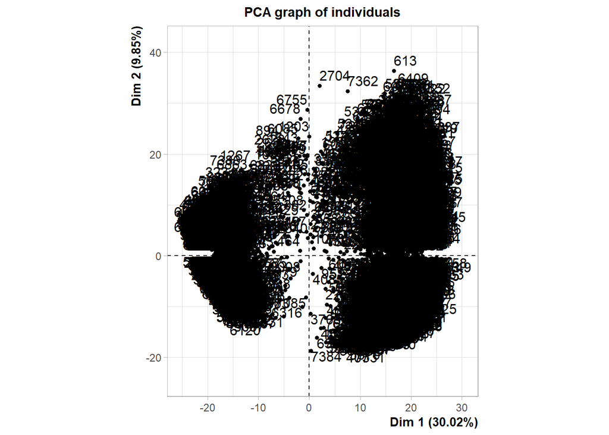

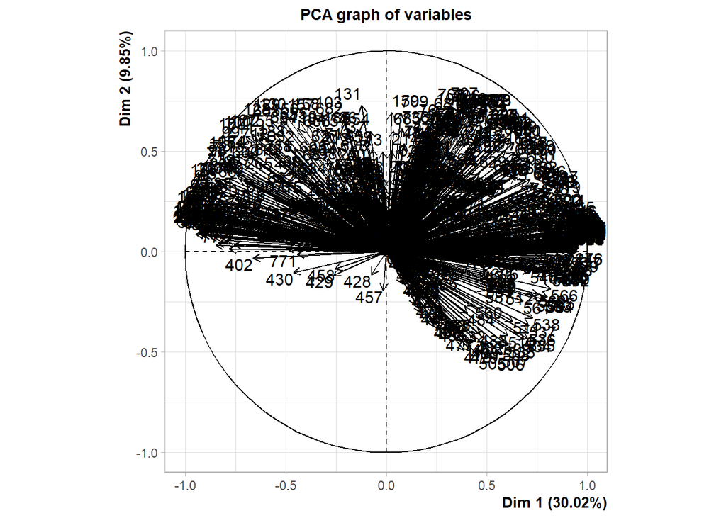

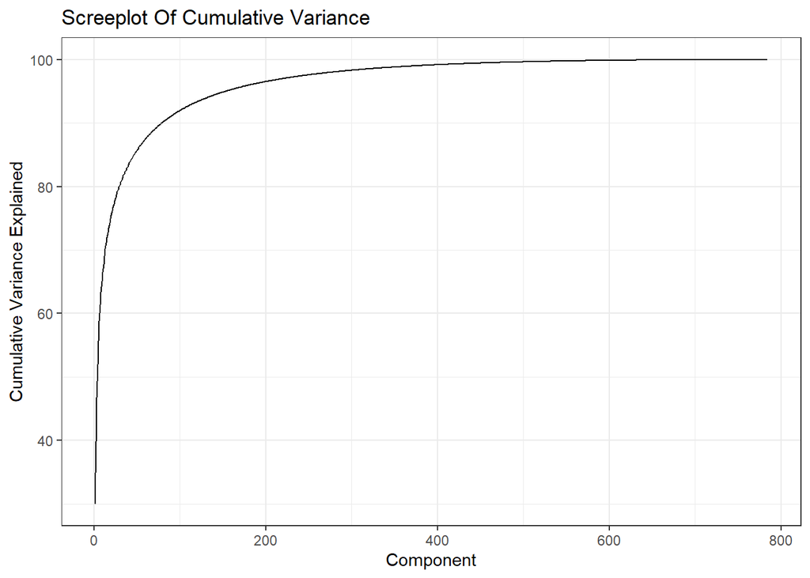

```r
screeplot_data <- as.data.frame(PCA_results$eig)
ggplot(data = screeplot_data, aes(x = 1:nrow(screeplot_data), y = screeplot_data[,3])) + geom_line() + theme_bw() + ylab("Cumulative Variance Explained") + xlab("Component") + ggtitle("Screeplot Of Cumulative Variance")
```

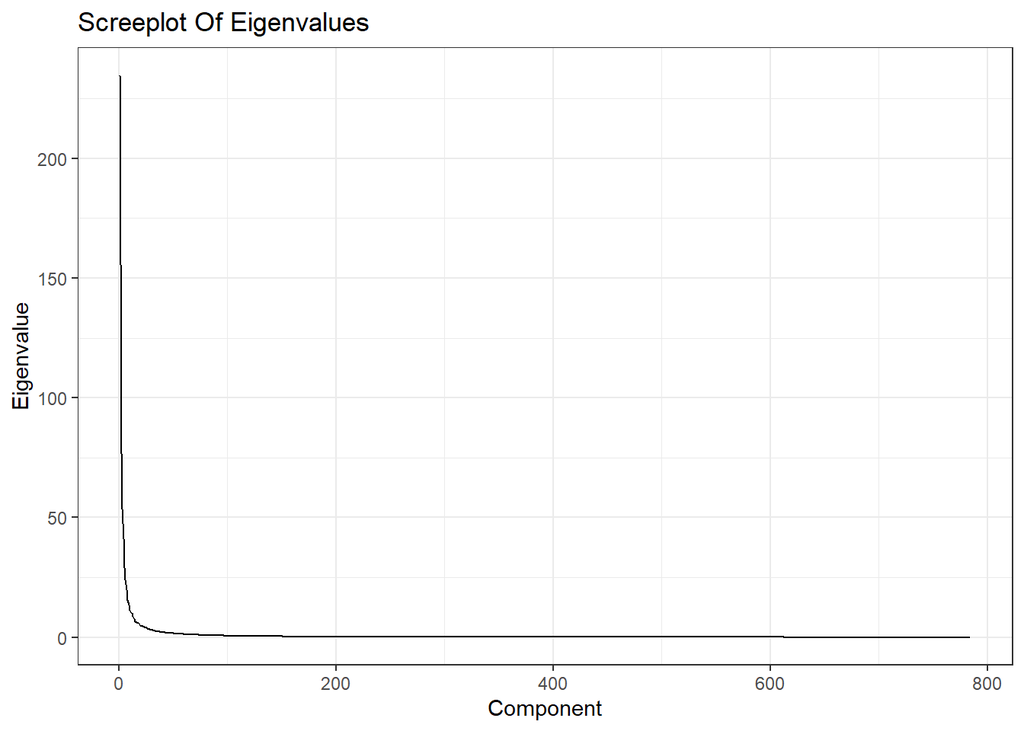

```r
ggplot(data = screeplot_data, aes(x = 1:nrow(screeplot_data), y = screeplot_data[,1])) + geom_line() + theme_bw() + ylab("Eigenvalue") + xlab("Component") + ggtitle("Screeplot Of Eigenvalues")
```

```r
loadings <- sweep(PCA_results$var$coord,2,sqrt(PCA_results$eig[1:ncol(PCA_results$var$coord),1]),FUN="/")

loadings <- abs(loadings)
loading_sums <- rowSums(loadings)
loadings_df <- cbind(loading_sums, c(1:length(loading_sums)))
loadings_df <- loadings_df[order(-loading_sums),]
colnames(loadings_df) <- c("loading sum", "columnnumber")

top_pic_pixels <- head(loadings_df[,2], 200)
X_compressed <- X[,sort(top_pic_pixels, decreasing = FALSE)]

shoes_pants_train_X <- X_compressed[shoes_pants_train,]
shoes_pants_test_X <- X_compressed[shoes_pants_test,]

shoes_pants_train_y <- as.factor(y[shoes_pants_train])
shoes_pants_test_y <- as.factor(y[shoes_pants_test])

shoes_pants_holdout_X <- X_compressed[holdout_shoes_pants,]
shoes_pants_holdout_y <- as.factor(y[holdout_shoes_pants])

trainingData <- cbind.data.frame(shoes_pants_train_X, shoes_pants_train_y)
testingData <- cbind.data.frame(shoes_pants_test_X, shoes_pants_test_y)
```

##### Gradient Boosted Machines Model with Cross-Validation

```r
objControl <- trainControl(method='cv', number=3, returnResamp='none', summaryFunction = twoClassSummary, classProbs = TRUE)

objModel <- train(shoes_pants_train_X, shoes_pants_train_y,
                  method='gbm',
                  trControl = objControl,
                  metric = "ROC")
objModel
```

```
## Stochastic Gradient Boosting
##
## 7680 samples
##  200 predictor
##    2 classes: 'pant', 'shoe'
##
## No pre-processing
## Resampling: Cross-Validated (3 fold)
## Summary of sample sizes: 5120, 5120, 5120
## Resampling results across tuning parameters:
##
##   interaction.depth  n.trees  ROC        Sens       Spec
##   1                   50      0.9999819  0.9976672  0.9971219
##   1                  100      0.9999984  0.9994816  0.9989534
##   1                  150      0.9999990  1.0000000  0.9992151
##   2                   50      0.9999919  0.9992224  0.9984301
##   2                  100      0.9999984  0.9994816  0.9986918
##   2                  150      0.9999994  0.9997408  0.9989534
##   3                   50      0.9999939  0.9997408  0.9984301
##   3                  100      0.9999976  0.9997408  0.9986918
##   3                  150      0.9999992  0.9997408  0.9989534
##
## Tuning parameter 'shrinkage' was held constant at a value of 0.1
##
## Tuning parameter 'n.minobsinnode' was held constant at a value of 10
## ROC was used to select the optimal model using the largest value.
## The final values used for the model were n.trees = 150, interaction.depth =
##  2, shrinkage = 0.1 and n.minobsinnode = 10.
```

```r
predictions <- predict(object=objModel, shoes_pants_test_X, type='raw')
head(predictions)
```

```
## [1] shoe shoe pant pant shoe pant
## Levels: pant shoe
```

```r
print(postResample(pred=predictions, obs=as.factor(shoes_pants_test_y)))
```

```
##  Accuracy     Kappa
## 0.9989583 0.9979159
```

```r
predictions <- predict(object=objModel, shoes_pants_test_X, type='prob')
head(predictions)
```

```
##           pant         shoe
## 1 0.0002362102 0.9997637898
## 2 0.0001513471 0.9998486529
## 3 0.9997351248 0.0002648752
## 4 0.9997351248 0.0002648752
## 5 0.0001309752 0.9998690248
## 6 0.9992046752 0.0007953248
```

##### Logistic Classification Model

```r
logitMod <- glm(shoes_pants_train_y ~ ., data=trainingData, family=binomial(link="logit"), maxit = 100)
fitted.results <- predict(logitMod,newdata=testingData,type='response')
fitted.results <- ifelse(fitted.results > 0.5,"shoe","pant")
misClassificError <- mean(fitted.results != testingData$shoes_pants_test_y)
print(paste('Accuracy',1-misClassificError))
```

```
## [1] "Accuracy 0.997395833333333"
```

Accuracy of this model is also very high but the GBM model bests it.

##### Final Model Testing With GBM

We selected GBM as the ultimate best model. The following results are obtained using the untouched holdout set.

```r
colnames(trainingData)[ncol(trainingData)] <- c("label")
colnames(testingData)[ncol(testingData)] <- c("label")

shoes_pants_data_final <- rbind.data.frame(trainingData, testingData)
shoes_pants_data_final$label <- (as.numeric(shoes_pants_data_final$label) - 1)
#pant is 0, shoe is 1
shoes_pants_holdout_final <- cbind.data.frame(shoes_pants_holdout_X, shoes_pants_holdout_y)
colnames(shoes_pants_holdout_final)[ncol(shoes_pants_holdout_final)] <- c("label")

model <- gbm(label ~ ., data = shoes_pants_data_final, n.trees = 150, interaction.depth = 2)
```

```
## Distribution not specified, assuming bernoulli ...
```

```r
model.pred <- predict(model, shoes_pants_holdout_final, n.trees = 150, type = "response")
model.pred <- ifelse(model.pred < 0.5, "pant", "shoe")
model.pred <- as.factor(model.pred)
confusionMatrix(model.pred, shoes_pants_holdout_final$label)
```

```
## Confusion Matrix and Statistics
##
##           Reference
## Prediction pant shoe
##       pant 1201    0
##       shoe    0 1199
##
##                Accuracy : 1
##                  95% CI : (0.9985, 1)
##     No Information Rate : 0.5004
##     P-Value [Acc > NIR] : < 2.2e-16
##
##                   Kappa : 1
##
##  Mcnemar's Test P-Value : NA
##
##             Sensitivity : 1.0000
##             Specificity : 1.0000
##          Pos Pred Value : 1.0000
##          Neg Pred Value : 1.0000
##              Prevalence : 0.5004
##          Detection Rate : 0.5004
##    Detection Prevalence : 0.5004
##       Balanced Accuracy : 1.0000
##
##        'Positive' Class : pant
##
```

#### Shirts VS Pants

The following code is a repeat of that above, except this time for “shirts” and “pants”.

```r
shirts_pants <- which(y %in% c("shirt","pant"))
holdout_shirts_pants_split <- sample.int(length(shirts_pants)*0.2)
holdout_shirts_pants <- shirts_pants[holdout_shirts_pants_split]
shirts_pants <- shirts_pants[-holdout_shirts_pants_split]
shirts_pants_train_split <- sample.int(length(shirts_pants)*0.8)
shirts_pants_train <- shirts_pants[shirts_pants_train_split]
shirts_pants_test <- shirts_pants[-shirts_pants_train_split]

PCA_results <- PCA(X[shirts_pants_train,], ncp = ncol(X))
```

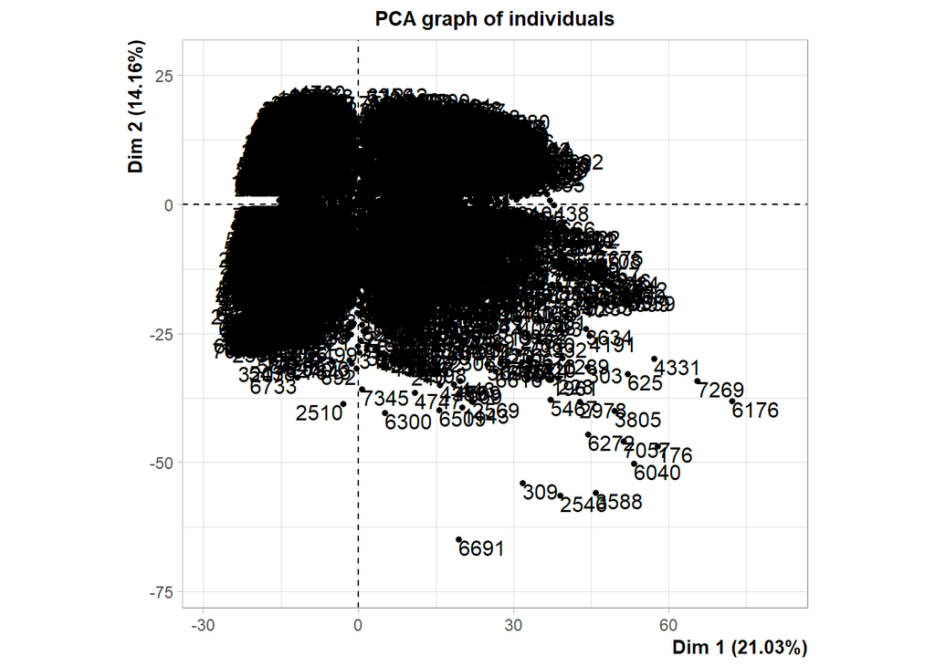

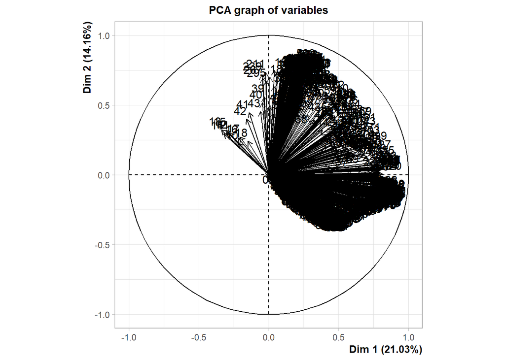

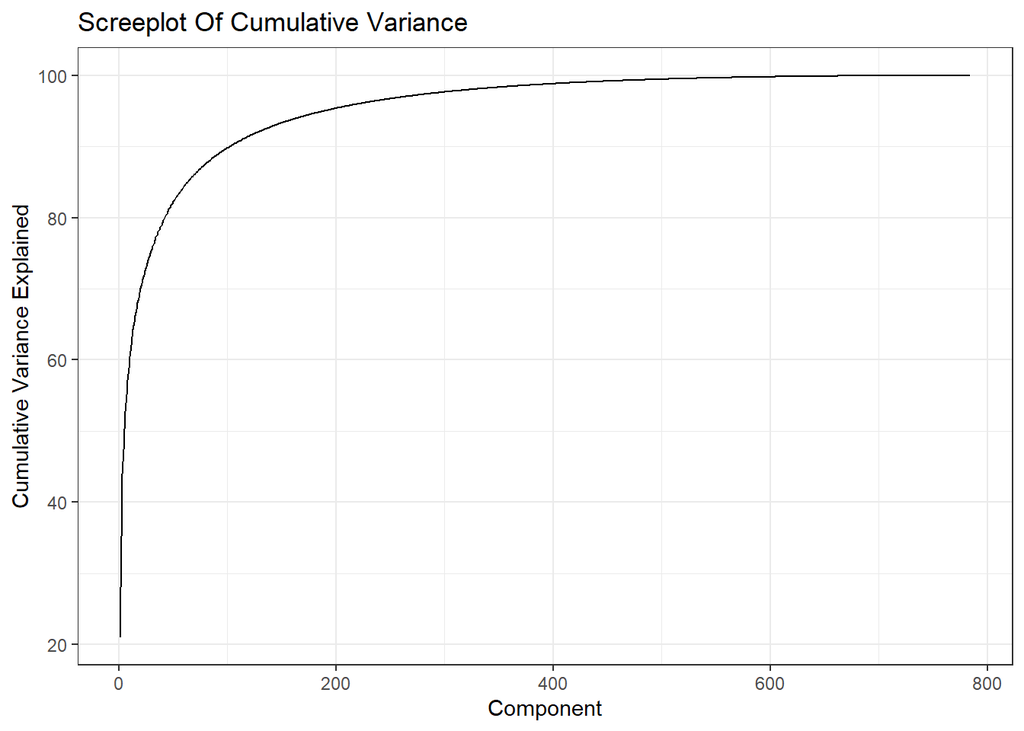

```r
screeplot_data <- as.data.frame(PCA_results$eig)
ggplot(data = screeplot_data, aes(x = 1:nrow(screeplot_data), y = screeplot_data[,3])) + geom_line() + theme_bw() + ylab("Cumulative Variance Explained") + xlab("Component") + ggtitle("Screeplot Of Cumulative Variance")
```

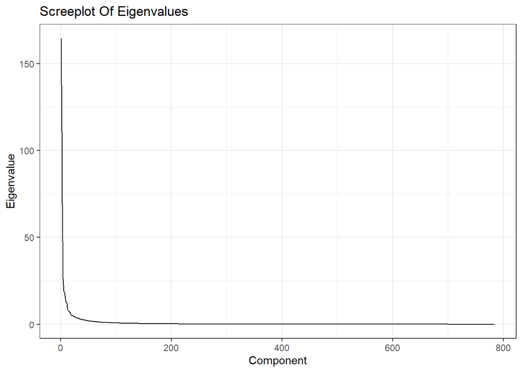

```r
ggplot(data = screeplot_data, aes(x = 1:nrow(screeplot_data), y = screeplot_data[,1])) + geom_line() + theme_bw() + ylab("Eigenvalue") + xlab("Component") + ggtitle("Screeplot Of Eigenvalues")
```

```r
loadings <- sweep(PCA_results$var$coord,2,sqrt(PCA_results$eig[1:ncol(PCA_results$var$coord),1]),FUN="/")

loadings <- abs(loadings)
loading_sums <- rowSums(loadings)
loadings_df <- cbind(loading_sums, c(1:length(loading_sums)))
loadings_df <- loadings_df[order(-loading_sums),]
colnames(loadings_df) <- c("loading sum", "columnnumber")

top_pic_pixels <- head(loadings_df[,2], 200)
X_compressed <- X[,sort(top_pic_pixels, decreasing = FALSE)]

shirts_pants_train_X <- X_compressed[shirts_pants_train,]
shirts_pants_test_X <- X_compressed[shirts_pants_test,]

shirts_pants_train_y <- as.factor(y[shirts_pants_train])
shirts_pants_test_y <- as.factor(y[shirts_pants_test])

shirts_pants_holdout_X <- X_compressed[holdout_shirts_pants,]
shirts_pants_holdout_y <- as.factor(y[holdout_shirts_pants])

trainingData <- cbind.data.frame(shirts_pants_train_X, shirts_pants_train_y)
testingData <- cbind.data.frame(shirts_pants_test_X, shirts_pants_test_y)
```

##### Gradient Boosted Machines Model with Cross-Validation

```r
objControl <- trainControl(method='cv', number=3, returnResamp='none', summaryFunction = twoClassSummary, classProbs = TRUE)

objModel <- train(shirts_pants_train_X, shirts_pants_train_y,
                  method='gbm',
                  trControl = objControl,
                  metric = "ROC")
objModel
```

```
## Stochastic Gradient Boosting
##
## 7680 samples
##  200 predictor
##    2 classes: 'pant', 'shirt'
##
## No pre-processing
## Resampling: Cross-Validated (3 fold)
## Summary of sample sizes: 5119, 5121, 5120
## Resampling results across tuning parameters:
##
##   interaction.depth  n.trees  ROC        Sens       Spec
##   1                   50      0.9957931  0.9663359  0.9742136
##   1                  100      0.9970081  0.9734370  0.9798849
##   1                  150      0.9972819  0.9742262  0.9814323
##   2                   50      0.9976754  0.9750145  0.9819477
##   2                  100      0.9982100  0.9784340  0.9847841
##   2                  150      0.9983351  0.9808010  0.9873631
##   3                   50      0.9981554  0.9779076  0.9832377
##   3                  100      0.9986052  0.9797488  0.9865895
##   3                  150      0.9987381  0.9831675  0.9873631
##
## Tuning parameter 'shrinkage' was held constant at a value of 0.1
##
## Tuning parameter 'n.minobsinnode' was held constant at a value of 10
## ROC was used to select the optimal model using the largest value.
## The final values used for the model were n.trees = 150, interaction.depth =
##  3, shrinkage = 0.1 and n.minobsinnode = 10.
```

```r
predictions <- predict(object=objModel, shirts_pants_test_X, type='raw')
head(predictions)
```

```
## [1] shirt shirt pant  pant  pant  shirt
## Levels: pant shirt
```

```r
print(postResample(pred=predictions, obs=as.factor(shirts_pants_test_y)))
```

```
##  Accuracy     Kappa
## 0.9817708 0.9635318
```

```r
predictions <- predict(object=objModel, shirts_pants_test_X, type='prob')
head(predictions)
```

```
##          pant       shirt
## 1 0.003460221 0.996539779
## 2 0.001855761 0.998144239
## 3 0.998110890 0.001889110
## 4 0.997668252 0.002331748
## 5 0.997425751 0.002574249
## 6 0.002749982 0.997250018
```

##### Logistic Classification Model

```r
logitMod <- glm(shirts_pants_train_y ~ ., data=trainingData, family=binomial(link="logit"), maxit = 100)
fitted.results <- predict(logitMod,newdata=testingData,type='response')
fitted.results <- ifelse(fitted.results > 0.5,"shirt","pant")
misClassificError <- mean(fitted.results != testingData$shirts_pants_test_y)
print(paste('Accuracy',1-misClassificError))
```

```
## [1] "Accuracy 0.965625"
```

Accuracy of this model is also very high but the GBM model bests it.

##### Final Model Testing With GBM

We selected GBM as the ultimate best model. The following results are obtained using the untouched holdout set.

```r
colnames(trainingData)[ncol(trainingData)] <- c("label")
colnames(testingData)[ncol(testingData)] <- c("label")

shirts_pants_data_final <- rbind.data.frame(trainingData, testingData)
shirts_pants_data_final$label <- (as.numeric(shirts_pants_data_final$label) - 1)
#pant is 0, shirt is 1
shirts_pants_holdout_final <- cbind.data.frame(shirts_pants_holdout_X, shirts_pants_holdout_y)
colnames(shirts_pants_holdout_final)[ncol(shirts_pants_holdout_final)] <- c("label")

model <- gbm(label ~ ., data = shirts_pants_data_final, n.trees = 150, interaction.depth = 2)
```

```
## Distribution not specified, assuming bernoulli ...
```

```r
model.pred <- predict(model, shirts_pants_holdout_final, n.trees = 150, type = "response")
model.pred <- ifelse(model.pred < 0.5, "pant", "shirt")
model.pred <- as.factor(model.pred)
confusionMatrix(model.pred, shirts_pants_holdout_final$label)
```

```
## Confusion Matrix and Statistics
##
##           Reference
## Prediction pant shirt
##      pant  1224    17
##      shirt   24  1135
##
##                Accuracy : 0.9829
##                  95% CI : (0.9769, 0.9877)
##     No Information Rate : 0.52
##     P-Value [Acc > NIR] : <2e-16
##
##                   Kappa : 0.9658
##
##  Mcnemar's Test P-Value : 0.3487
##
##             Sensitivity : 0.9808
##             Specificity : 0.9852
##          Pos Pred Value : 0.9863
##          Neg Pred Value : 0.9793
##              Prevalence : 0.5200
##          Detection Rate : 0.5100
##    Detection Prevalence : 0.5171
##       Balanced Accuracy : 0.9830
##
##        'Positive' Class : pant
##
```

### Multiclass Classification

The following code is similar to the code for binary classification.

```r
all <- 1:length(y)
holdout_all_split <- sample.int(length(y)*0.2)
holdout_all <- all[holdout_all_split]
all <- all[-holdout_all_split]
all_train_split <- sample.int(length(all)*0.8)
all_train <- all[all_train_split]
all_test <- all[-all_train_split]

PCA_results <- PCA(X[all_train,], ncp = ncol(X))
```

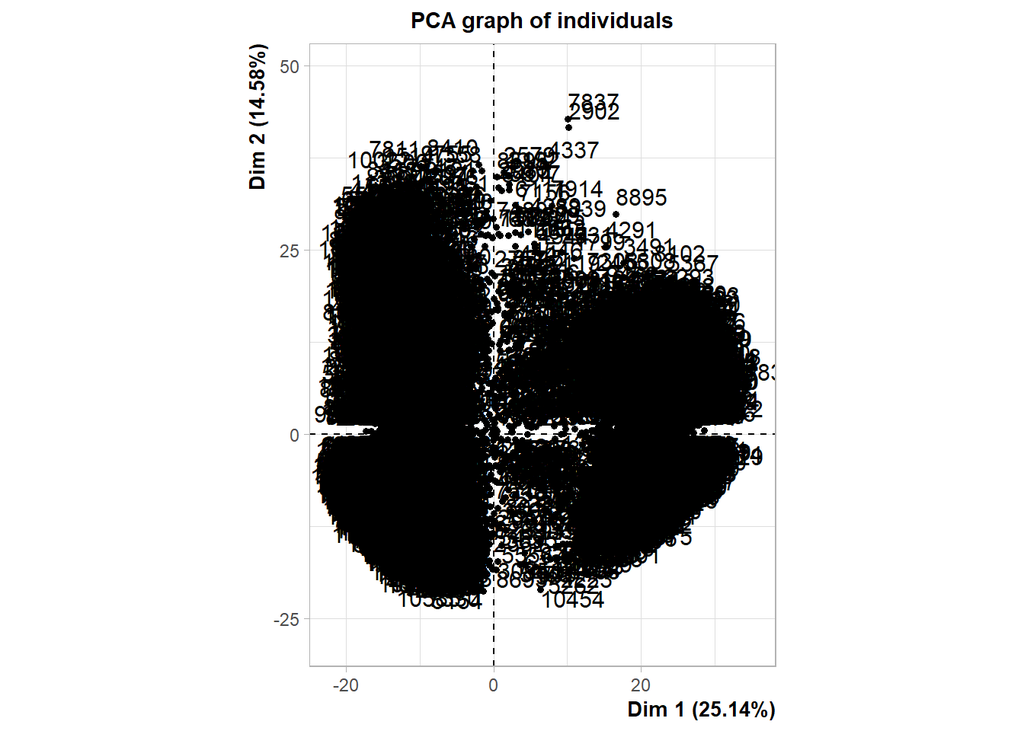

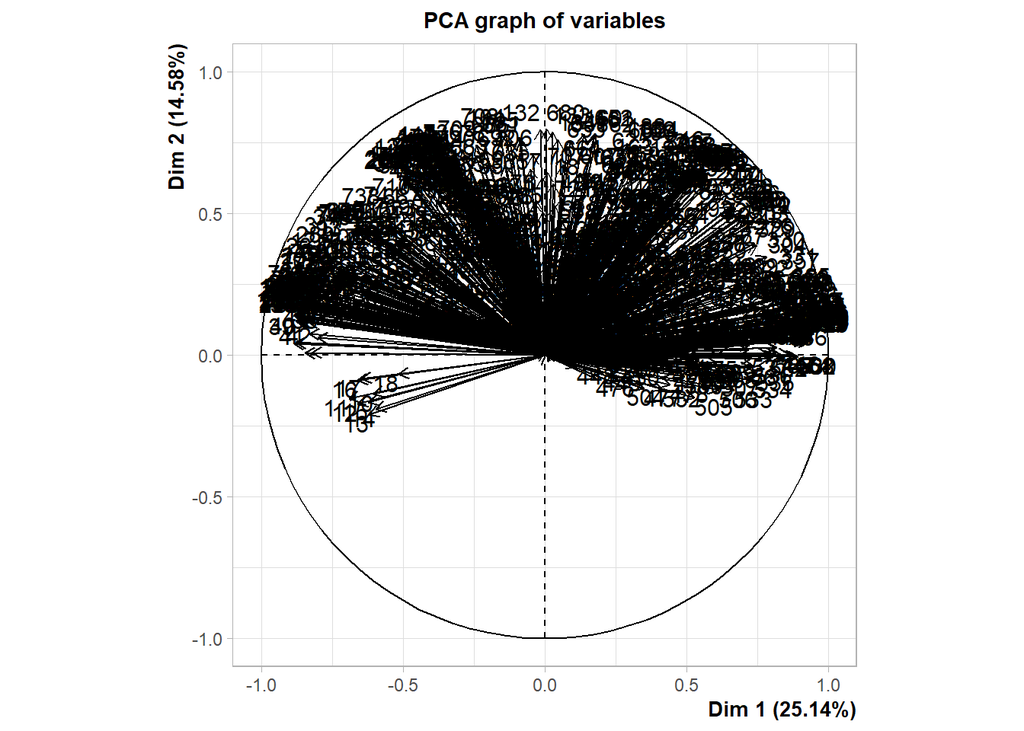

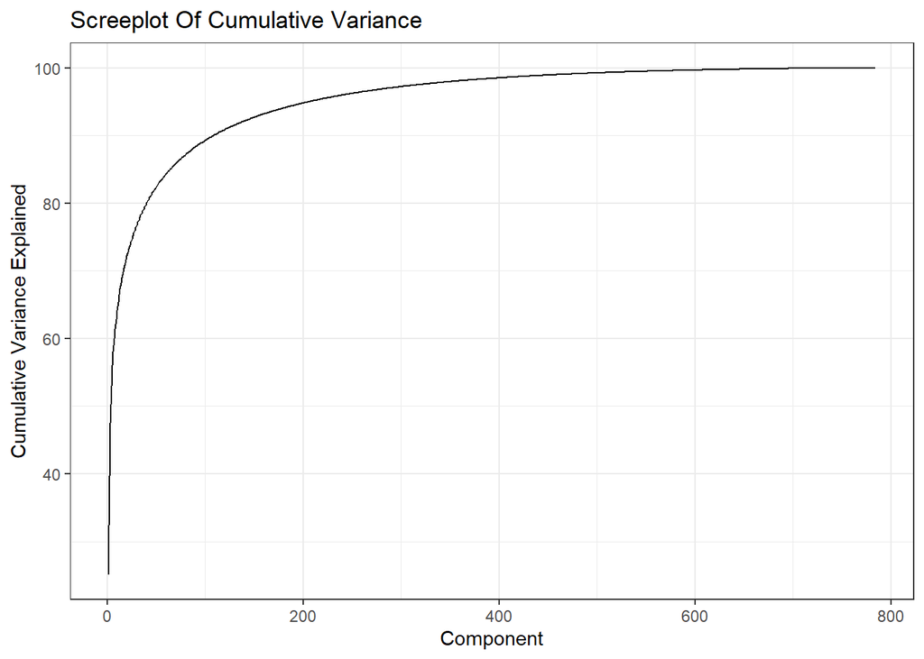

```r
loadings <- sweep(PCA_results$var$coord,2,sqrt(PCA_results$eig[1:ncol(PCA_results$var$coord),1]),FUN="/")

screeplot_data <- as.data.frame(PCA_results$eig)
ggplot(data = screeplot_data, aes(x = 1:nrow(screeplot_data), y = screeplot_data[,3])) + geom_line() + theme_bw() + ylab("Cumulative Variance Explained") + xlab("Component") + ggtitle("Screeplot Of Cumulative Variance")
```

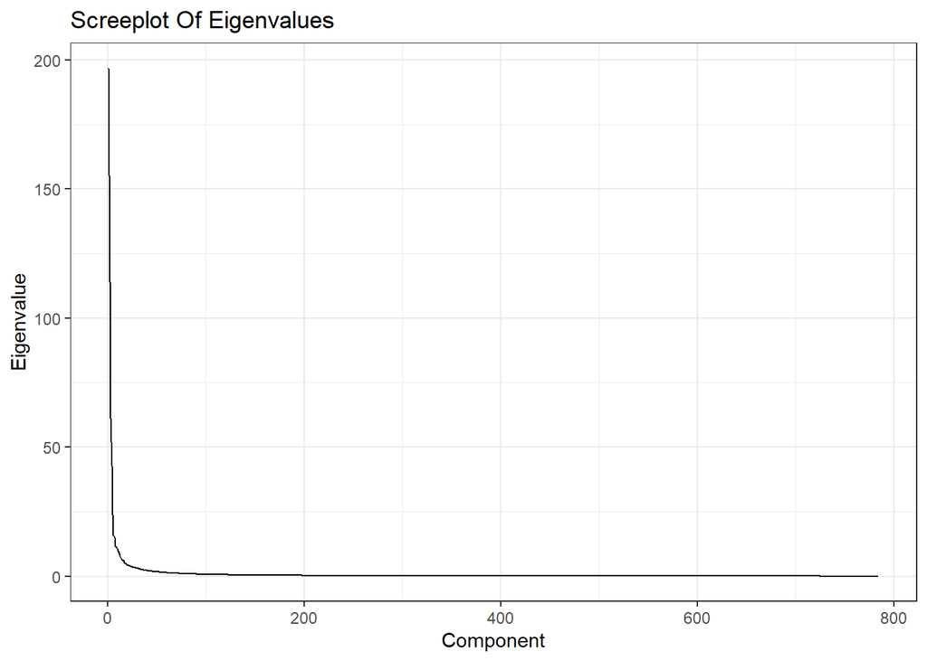

```r
ggplot(data = screeplot_data, aes(x = 1:nrow(screeplot_data), y = screeplot_data[,1])) + geom_line() + theme_bw() + ylab("Eigenvalue") + xlab("Component") + ggtitle("Screeplot Of Eigenvalues")
```

```r
loadings <- abs(loadings)
loading_sums <- rowSums(loadings)
loadings_df <- cbind(loading_sums, c(1:length(loading_sums)))
loadings_df <- loadings_df[order(-loading_sums),]
colnames(loadings_df) <- c("loading sum", "columnnumber")

top_pic_pixels <- head(loadings_df[,2], 200)
X_compressed <- X[,sort(top_pic_pixels, decreasing = FALSE)]

all_train_X <- X_compressed[all_train,]
all_test_X <- X_compressed[all_test,]

all_train_y <- as.factor(y[all_train])
all_test_y <- as.factor(y[all_test])

all_holdout_X <- X_compressed[holdout_all,]
all_holdout_y <- as.factor(y[holdout_all])

trainingData <- cbind.data.frame(all_train_X, all_train_y)
testingData <- cbind.data.frame(all_test_X, all_test_y)
```

##### Gradient Boosted Machines Model with Cross-Validation

```r
objControl <- trainControl(method='cv', number=3, classProbs = TRUE)

objModel <- train(all_train_y ~ .,
                  data = trainingData,
                  method='gbm',
                  trControl = objControl,
                  metric = "ROC")
objModel
```

```
## Stochastic Gradient Boosting
##
## 11520 samples
##   200 predictor
##     3 classes: 'pant', 'shirt', 'shoe'
##
## No pre-processing
## Resampling: Cross-Validated (3 fold)
## Summary of sample sizes: 7678, 7681, 7681
## Resampling results across tuning parameters:
##
##   interaction.depth  n.trees  Accuracy   Kappa
##   1                   50      0.9850694  0.9776016
##   1                  100      0.9884551  0.9826811
##   1                  150      0.9886285  0.9829413
##   2                   50      0.9886284  0.9829410
##   2                  100      0.9900174  0.9850248
##   2                  150      0.9902776  0.9854153
##   3                   50      0.9895833  0.9843736
##   3                  100      0.9908853  0.9863270
##   3                  150      0.9912323  0.9868475
##
## Tuning parameter 'shrinkage' was held constant at a value of 0.1
##
## Tuning parameter 'n.minobsinnode' was held constant at a value of 10
## Accuracy was used to select the optimal model using the largest value.
## The final values used for the model were n.trees = 150, interaction.depth =
##  3, shrinkage = 0.1 and n.minobsinnode = 10.
```

```r
predictions <- predict(object=objModel, all_test_X, type='raw')
head(predictions)
```

```
## [1] shirt shirt pant  pant  pant  shoe
## Levels: pant shirt shoe
```

```r
print(postResample(pred=predictions, obs=as.factor(all_test_y)))
```

```
##  Accuracy     Kappa
## 0.9895833 0.9843720
```

```r
predictions <- predict(object=objModel, all_test_X, type='prob')
head(predictions)
```

```
##           pant        shirt         shoe
## 1 0.0004242282 9.995573e-01 1.845115e-05
## 2 0.0002883540 9.997035e-01 8.115263e-06
## 3 0.9996773320 3.157901e-04 6.877842e-06
## 4 0.9995362912 4.470005e-04 1.670825e-05
## 5 0.9825846550 1.723807e-02 1.772725e-04
## 6 0.0000172782 8.858449e-05 9.998941e-01
```

##### Support Vector Machines Model

```r
colnames(trainingData)[ncol(trainingData)] <- c("label")
colnames(testingData)[ncol(testingData)] <- c("label")

svm_model <- svm(label ~ ., data=trainingData,
          method="C-classification", kernel="radial")

summary(svm_model)
```

```
##
## Call:
## svm(formula = label ~ ., data = trainingData, method = "C-classification",
##     kernel = "radial")
##
##
## Parameters:
##    SVM-Type:  C-classification
##  SVM-Kernel:  radial
##        cost:  1
##
## Number of Support Vectors:  864
##
##  ( 446 150 268 )
##
##
## Number of Classes:  3
##
## Levels:
##  pant shirt shoe
```

```r
prediction <- predict(svm_model, testingData)

confusionMatrix(prediction, testingData$label)
```

```
## Confusion Matrix and Statistics
##
##           Reference
## Prediction pant shirt shoe
##      pant   913     3    0
##      shirt   26   961    0
##      shoe     0     1  976
##
## Overall Statistics
##
##                Accuracy : 0.9896
##                  95% CI : (0.9852, 0.993)
##     No Information Rate : 0.3389
##     P-Value [Acc > NIR] : < 2.2e-16
##
##                   Kappa : 0.9844
##
##  Mcnemar's Test P-Value : NA
##
## Statistics by Class:
##
##                      Class: pant Class: shirt Class: shoe
## Sensitivity               0.9723       0.9959      1.0000
## Specificity               0.9985       0.9864      0.9995
## Pos Pred Value            0.9967       0.9737      0.9990
## Neg Pred Value            0.9868       0.9979      1.0000
## Prevalence                0.3260       0.3351      0.3389
## Detection Rate            0.3170       0.3337      0.3389
## Detection Prevalence      0.3181       0.3427      0.3392
## Balanced Accuracy         0.9854       0.9911      0.9997
```

The accuracy for this model is another very high result, however it still doesn’t beat the best GBM model.

#### Combining Three Binary Models To Predict Multiclass

In order to do this, one must repeat the binary classification code above for splitting the data and making the model. However, PCA must be run first on the full data set just like the most recent PCA for multiclass classification. That way, the PCA results transform the full dataset and then each binary model is built afterwards using the same dataset predictor variables. After that, run the test set entries on each model and output a matrix of responses. For each row in the matrix, it would have 3 columns, one for each model prediction. The most common prediction per row is the ultimate prediction in the end of the multiclass model. Then make a confusion matrix to test the accuracy.

#### Final Model Testing With GBM

We selected GBM as the ultimate best model. The following results are obtained using the untouched holdout set

```r
all_data_final <- rbind.data.frame(trainingData, testingData)
all_holdout_final <- cbind.data.frame(all_holdout_X, all_holdout_y)
colnames(all_holdout_final)[ncol(all_holdout_final)] <- c("label")

model <- gbm(label ~ ., data = all_data_final, n.trees = 150, interaction.depth = 3)
```

```
## Distribution not specified, assuming multinomial ...
```

```r
model.pred <- predict(model, all_holdout_final, n.trees = 150, type = "response")
model.pred <- matrix(model.pred, ncol = 3)
colnames(model.pred) <- c("pant", "shirt", "shoe")
model.pred <- as.factor(colnames(model.pred)[max.col(model.pred)])
confusionMatrix(model.pred, all_holdout_final$label)
```

```
## Confusion Matrix and Statistics
##
##           Reference
## Prediction pant shirt shoe
##      pant  1216    13    0
##      shirt   16  1120    1
##      shoe     0     1 1233
##
## Overall Statistics
##
##                Accuracy : 0.9914
##                  95% CI : (0.9878, 0.9941)
##     No Information Rate : 0.3428
##     P-Value [Acc > NIR] : < 2.2e-16
##
##                   Kappa : 0.9871
##
##  Mcnemar's Test P-Value : NA
##
## Statistics by Class:
##
##                      Class: pant Class: shirt Class: shoe
## Sensitivity               0.9870       0.9877      0.9992
## Specificity               0.9945       0.9931      0.9996
## Pos Pred Value            0.9894       0.9850      0.9992
## Neg Pred Value            0.9933       0.9943      0.9996
## Prevalence                0.3422       0.3150      0.3428
## Detection Rate            0.3378       0.3111      0.3425
## Detection Prevalence      0.3414       0.3158      0.3428
## Balanced Accuracy         0.9908       0.9904      0.9994
```

With our final selected model, the predictions on the test set yield an ultimate accuracy of roughly 99% which is due to the large number of trees used in the boosting of the algorithm and the PCA which we use to let the algorithm focus on the most significant pixels across the entire dataset. Looking at the dataset as a whole, we understand intuitively that there is a large difference between, for example, a shoe and a shirt or pants and a shirt. Therefore, it seems reasonable that a sufficiently soffisticated model should be able to accurately and consistently sort through these various clothing items. If, perhaps, we had trained this model on a wider variety of clothing items, such as different types of shoes or shirts and such, the result would not have been quite as effective.